# Part A. Setup and data.

## Loading everything we will need.

I start with the imports.

```python
import numpy as np
import pandas as pd
import matplotlib.pyplot as plt

from sklearn.datasets import fetch_openml
from sklearn.model_selection import train_test_split, cross_val_score, StratifiedKFold
from sklearn.compose import ColumnTransformer
from sklearn.pipeline import Pipeline
from sklearn.impute import SimpleImputer
from sklearn.preprocessing import StandardScaler, OneHotEncoder, LabelEncoder
from sklearn.linear_model import LogisticRegression
from sklearn.metrics import (accuracy_score, f1_score,
                             confusion_matrix, ConfusionMatrixDisplay)

import keras
from keras import layers
```

## Loading the data.

I download the Adult data set from OpenML. The features arrive in `X` as a table, and the target in `y` as text, either `>50K` or `<=50K`.

```python
X, y = fetch_openml("adult", version=2, as_frame=True, return_X_y=True)

print("Rows and columns:", X.shape)
print("Target values:", y.value_counts().to_dict())
print(X.head())
```

```
Rows and columns: (48842, 14)
Target values: {'<=50K': 37155, '>50K': 11687}
   age  workclass  fnlwgt     education  education-num      marital-status  \
0   25    Private  226802          11th              7       Never-married
1   38    Private   89814       HS-grad              9  Married-civ-spouse
2   28  Local-gov  336951    Assoc-acdm             12  Married-civ-spouse
3   44    Private  160323  Some-college             10  Married-civ-spouse
4   18        NaN  103497  Some-college             10       Never-married

          occupation relationship   race     sex  capital-gain  capital-loss  \
0  Machine-op-inspct    Own-child  Black    Male             0             0
1    Farming-fishing      Husband  White    Male             0             0
2    Protective-serv      Husband  White    Male             0             0
3  Machine-op-inspct      Husband  Black    Male          7688             0
4                NaN    Own-child  White  Female             0             0

   hours-per-week native-country
0              40  United-States
1              50  United-States
2              40  United-States
3              40  United-States
4              30  United-States
```

## Encoding the target.

```
The target is text with two values. I convert it to numbers so both models
can use it. LabelEncoder maps the two classes to 0 and 1 in alphabetical
order, so <=50K becomes 0 and >50K becomes 1. The higher income class is
therefore the positive class, labelled 1.
```

```python
y = LabelEncoder().fit_transform(y)
print("Positive rate (share earning >50K):", round(y.mean(), 3))
```

```
Positive rate (share earning >50K): 0.239
```

## Train and test split.

```
I split the data into a training set and a test set before doing anything
else, and I keep the class balance with stratify. Both models are trained
on the training set and judged on the same held-back test set.
```

```python
X_train, X_test, y_train, y_test = train_test_split(
    X, y, test_size=0.2, random_state=42, stratify=y)

print("Training rows:", X_train.shape[0])
print("Test rows:    ", X_test.shape[0])
```

```
Training rows: 39073
Test rows:     9769
```

## Numeric and categorical columns.

```
These two kinds of feature need different preprocessing, so I sort the
columns into a numeric group and a categorical group.
I detect them from the column data types.
```

```python
numeric_features = X_train.select_dtypes(include="number").columns.tolist()
categorical_features = X_train.select_dtypes(exclude="number").columns.tolist()

print("Numeric features:", numeric_features)
print("Categorical features:", categorical_features)
```

```
Numeric features: ['age', 'fnlwgt', 'education-num', 'capital-gain', 'capital-loss', 'hours-per-week']
Categorical features: ['workclass', 'education', 'marital-status', 'occupation', 'relationship', 'race', 'sex', 'native-country']
```

# Part B. The classical model.

## Preprocessor with a ColumnTransformer.

### For the NUMERIC columns,

```
I chain two steps in a Pipeline:
    -SimpleImputer to fill missing values (strategy="median")
    -StandardScaler to put the features on the same scale.
```

```python
numeric_pipe = Pipeline([
    ("imputer", SimpleImputer(strategy="median")),
    ("scaler", StandardScaler()),
])
```

### For the CATEGORICAL columns,

```
I chain two steps in a Pipeline:
  -SimpleImputer to fill missing values (strategy="most_frequent")
  -OneHotEncoder to turn categories into numbers.
I set:
  -handle_unknown="ignore", so unseen categories in the test set do not error
  -sparse_output=False, so the result is a plain array the network can use
  later.
```

```python
categorical_pipe = Pipeline([
    ("imputer", SimpleImputer(strategy="most_frequent")),
    ("onehot", OneHotEncoder(handle_unknown="ignore", sparse_output=False))
])
```

Then I combine the two with a ColumnTransformer, applying each pipeline to its own list of columns (numeric_features and categorical_features).

```python
preprocess = ColumnTransformer(
    transformers=[
        ("num", numeric_pipe, numeric_features),
        ("categ", categorical_pipe, categorical_features),
        ],
        remainder="drop",
)
```

I combine the preprocessor and a LogisticRegression into one Pipeline, so that preprocessing is fitted only on the training data inside each fold. LogisticRegression(max_iter=1000) gives it enough iterations to converge.

```python
pipe = Pipeline([
    ("preprocess", preprocess),
    ("model", LogisticRegression(max_iter=1000))
])
print(pipe)
```

```
Pipeline(steps=[('preprocess',
                 ColumnTransformer(transformers=[('num',
                                                  Pipeline(steps=[('imputer',
                                                                   SimpleImputer(strategy='median')),
                                                                  ('scaler',
                                                                   StandardScaler())]),
                                                  ['age', 'fnlwgt',
                                                   'education-num',
                                                   'capital-gain',
                                                   'capital-loss',
                                                   'hours-per-week']),
                                                 ('categ',
                                                  Pipeline(steps=[('imputer',
                                                                   SimpleImputer(strategy='most_frequent')),
                                                                  ('onehot',
                                                                   OneHotEncoder(handle_unknown='ignore',
                                                                                 sparse_output=False))]),
                                                  ['workclass', 'education',
                                                   'marital-status',
                                                   'occupation', 'relationship',
                                                   'race', 'sex',
                                                   'native-country'])])),
                ('model', LogisticRegression(max_iter=1000))])
```

I run a 5-fold cross-validation on the TRAINING data, scoring by F1 and using StratifiedKFold(n_splits=5, shuffle=True, random_state=42).

```python
cv = StratifiedKFold(
    n_splits=5,
    shuffle=True,
    random_state=42
)
```

```python
cv_scores = cross_val_score(
        pipe,
    X_train,
    y_train,
    cv=cv,
    scoring="f1",
    n_jobs=1
)
```

```python
print("F1 Score:", cv_scores)
print("Mean F1:", cv_scores.mean().round(4))
print("Standard Deviation:", cv_scores.std().round(4))
```

```
F1 Score: [0.67144564 0.66647111 0.65281899 0.64542531 0.65165253]
Mean F1: 0.6576
Standard Deviation: 0.0098
```

I fit the classifier(clf) on the training data, then predict on the test data. I store the results so I can compare them later. Then I draw the confusion matrix for the classical model.

```
Accuracy: 0.8524
F1 score: 0.6562
```

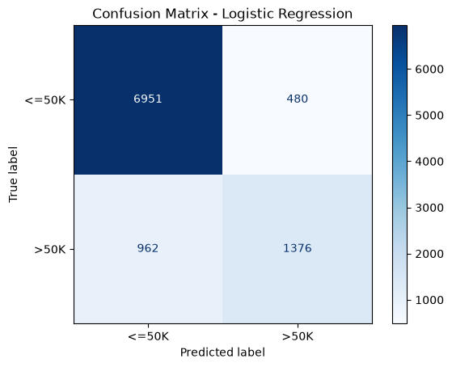

```python
pipe.fit(
    X_train,
    y_train
)
y_predict = pipe.predict(X_test)

clf_acc = round(accuracy_score(y_test, y_predict), 4)
clf_f1 = round(f1_score(y_test, y_predict), 4)

print("Accuracy:", clf_acc)
print("F1 score:", clf_f1)

ConfusionMatrixDisplay.from_predictions(
    y_test,
    y_predict,
    display_labels=["<=50K", ">50K"],
    cmap="Blues"
)

plt.title("Confusion Matrix - Logistic Regression")
plt.show(block=False)
plt.pause(1)
plt.close()

# The code above was necessary because it was interfering when running
# the script from top to bottom.
```

## Part C. The neural network.

### Before building the neural network, make a prediction.

Do you expect its F1 score to be higher than, lower than, or similar to that of logistic regression? Do you expect a large or a small difference? Briefly explain your reasoning.

MY PREDICTION: I expect the F1 score to be similar to that of logistic regression, with only a small difference. Logistic regression is already a strong baseline for this tabular data after numeric scaling and categorical one-hot encoding. The neural network may learn some nonlinear interactions, but its improvement is unlikely to be large because the input representation and the underlying task are well suited to a linear model.

A neural network needs a plain numeric array as input, so I apply the preprocessor to turn the mixed table into numbers. I fit the preprocessor on the training data only, then transform both sets, so no information leaks from the test set.

```python
X_train_prep = preprocess.fit_transform(X_train)   # fit on training data only
X_test_prep  = preprocess.transform(X_test)        # reuse the same fitting

print("Training shape:", X_train_prep.shape)
```

```
Training shape: (39073, 105)
```

### I build a dense network with the Keras Sequential API.

```
 -an Input layer whose shape is the number of columns in X_train_prep (X_train_prep.shape[1])
 -a Dense hidden layer (try 64 units, relu)
 -a Dropout layer (0.3) to reduce overfitting
 -a second Dense hidden layer (try 32 units, relu)
 -a Dense output layer with 1 unit and a sigmoid activation
```

```python
net = keras.Sequential([
    layers.Input(shape=(X_train_prep.shape[1],)),
    layers.Dense(64, activation="relu"),
    layers.Dropout(0.3),
    layers.Dense(32, activation="relu"),
    layers.Dense(1, activation="sigmoid")
])

net.summary()
```

```
Model: "sequential"
```

```
┏━━━━━━━━━━━━━━━━━━━━━━━━━━━━━━━━━┳━━━━━━━━━━━━━━━━━━━━━━━━┳━━━━━━━━━━━━━━━┓
┃ Layer (type)                    ┃ Output Shape           ┃       Param # ┃
┡━━━━━━━━━━━━━━━━━━━━━━━━━━━━━━━━━╇━━━━━━━━━━━━━━━━━━━━━━━━╇━━━━━━━━━━━━━━━┩
│ dense (Dense)                   │ (None, 64)             │         6,784 │
├─────────────────────────────────┼────────────────────────┼───────────────┤
│ dropout (Dropout)               │ (None, 64)             │             0 │
├─────────────────────────────────┼────────────────────────┼───────────────┤
│ dense_1 (Dense)                 │ (None, 32)             │         2,080 │
├─────────────────────────────────┼────────────────────────┼───────────────┤
│ dense_2 (Dense)                 │ (None, 1)              │            33 │
└─────────────────────────────────┴────────────────────────┴───────────────┘
```

```
 Total params: 8,897 (34.75 KB)
```

```
 Trainable params: 8,897 (34.75 KB)
```

```
 Non-trainable params: 0 (0.00 B)
```

### I compile net with:

```
-optimizer="adam",
-loss="binary_crossentropy",
-metrics=["accuracy"]
```

### Then I train it with:

```
-an explicit 10% validation set,
-an EarlyStopping callback (monitor "val_loss",
-patience about 3, restore_best_weights=True),
-up to about 20 epochs, and
-batch_size=128.
```

I store the result in history.

```python
net.compile(
    optimizer="adam",
    loss="binary_crossentropy",
    metrics=["accuracy"]
)

early_stopping = keras.callbacks.EarlyStopping(
    monitor="val_loss",
    patience=3,
    restore_best_weights=True
)

history = net.fit(
    X_train_prep,
    y_train,
    validation_split=0.1,
    callbacks=[early_stopping],
    epochs=20,
    batch_size=128
)
```

```
WARNING:tensorflow:TensorFlow GPU support is not available on native Windows for TensorFlow >= 2.11. Even if CUDA/cuDNN are installed, GPU will not be used. Please use WSL2 or the TensorFlow-DirectML plugin.
```

```
275/275 ━━━━━━━━━━━━━━━━━━━━ 3s 3ms/step - accuracy: 0.8252 - loss: 0.3725 - val_accuracy: 0.8498 - val_loss: 0.3302
275/275 ━━━━━━━━━━━━━━━━━━━━ 1s 2ms/step - accuracy: 0.8500 - loss: 0.3203 - val_accuracy: 0.8503 - val_loss: 0.3305
275/275 ━━━━━━━━━━━━━━━━━━━━ 1s 2ms/step - accuracy: 0.8548 - loss: 0.3122 - val_accuracy: 0.8547 - val_loss: 0.3260
275/275 ━━━━━━━━━━━━━━━━━━━━ 1s 2ms/step - accuracy: 0.8558 - loss: 0.3092 - val_accuracy: 0.8557 - val_loss: 0.3274
275/275 ━━━━━━━━━━━━━━━━━━━━ 1s 2ms/step - accuracy: 0.8576 - loss: 0.3077 - val_accuracy: 0.8541 - val_loss: 0.3293
275/275 ━━━━━━━━━━━━━━━━━━━━ 1s 2ms/step - accuracy: 0.8580 - loss: 0.3056 - val_accuracy: 0.8552 - val_loss: 0.3283
```

Now I produce predictions and evaluate the network. Then I compute nn_acc and nn_f1, printing them, and draw the confusion matrix.

```
306/306 ━━━━━━━━━━━━━━━━━━━━ 0s 1ms/step
Accuracy NN: 0.8561
F1 Score NN: 0.6744
```

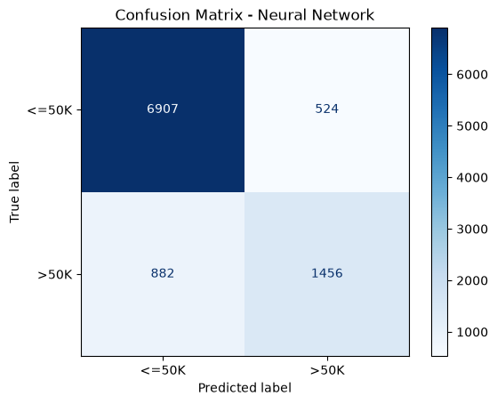

```python
nn_prob = net.predict(X_test_prep).ravel()     # probabilities
nn_pred = (nn_prob > 0.5).astype(int)           # threshold at 0.5

nn_acc = round(accuracy_score(y_test, nn_pred), 4)
nn_f1 = round(f1_score(y_test, nn_pred), 4)

print("Accuracy NN:", nn_acc)
print("F1 Score NN:", nn_f1)

ConfusionMatrixDisplay.from_predictions(
    y_test,
    nn_pred,
    display_labels=["<=50K", ">50K"],
    cmap="Blues"
)

plt.title("Confusion Matrix - Neural Network")
plt.show()
```

## Part D. The comparison.

Now we answer the central question. We have four numbers: the accuracy and F1 of the classical model, and the accuracy and F1 of the network, all measured on the same test set

```python
print("Model Comparison:")
print(f"Logistic Regression F1: {clf_f1:.4f}")
print(f"Logistic Regression Accuracy: {clf_acc:.4f}")
print(f"Neural Network F1: {nn_f1:.4f}")
print(f"Neural Network Accuracy: {nn_acc:.4f}")
```

```
Model Comparison:
Logistic Regression F1: 0.6562
Logistic Regression Accuracy: 0.8524
Neural Network F1: 0.6744
Neural Network Accuracy: 0.8561
```

# Ethical considerations

here are a few ethical risks we have to consider before deploying this model. Firstly, a model that uses characteristics like sex, race, and country of origin in order to predict their income bracket is incredibly sensitive to reproducing existing inequalities. Ensuring equity and fairness is a priority. For public benefit programmes, a false negative may exclude someone who needs support, while a false positive may waste resources. Those mistakes have great real-world cost for people, agencies, and government, defeating also the purpose of the programme and wasting funds. In my view, such considerations make a simpler, more transparent model more preferable to an opaque one when decisions affect people.

# Wrapping up

While accuracy is a very important metric, we should emphasise that a single number cannot tell us the whole story and might mislead us into a false sense of confidence about how well our model is learning and performing. Firstly, accuracy is important in the case of a reasonably balanced data set; this dataset is imbalanced. The majority class has more examples, it contributes more to the overall loss. The model might not be performing well on the minority class. F1 is the more informative metric, because it balances precision and recall for the positive, minority class (>50K). However, F1 does not measure fairness across demographic groups. F1 is your main comparison metric and accuracy as supporting information.

The network required a few more careful steps, due to its greater complexity. On this data set and setting, the extra complexity of this model resulted in slightly better predictions when compared to the simpler model. The Adult dataset is large enough for the neural network to learn some nonlinear interactions between features such as education, occupation, age, and hours worked. These interactions may explain its slightly higher F1 score, although the one-hot encoded tabular structure also makes logistic regression a strong and competitive baseline.